# Usando regressão linear para explicar a votação de deputados

Ivyna Santino

26 de setembro de 2018

Dicionário das variáveis:

- sequencial_candidato: id do candidato
- nome: nome do deputado
- uf: estado
- partido: partido do deputado
- quantidade_doacoes: número de doações diferentes
- quantidade_doadores: número de doadores diferentes
- total_receita: soma em R$ das doações
- media_receita: média das doações
- recursos_de_outros_candidatos/comites: quantia em R$ das doações provenientes de outros candidatos ou comite partidário
- recursos_de_pessoas_fisicas: quantia em R$ das doações provenientes de outros CPFs
- recursos_de_pessoas_juridicas: quantia em R$ das doações provenientes de outros CNPJ
- recursos_proprios“: quantia em R$ das doações provenientes do próprio candidato
- recursos_de_partido_politico: quantia em R$ das doações provenientes do partido político do candidato
- votos: variável alvo. Se refere ao número de votos na campanha de 2006 e 2010
- quantidade_despesas
- quantidade_fornecedores: número de fornecedores/despesas diferentes
- total_despesa: soma em R$ das despesas de campanha
- media_despesa: média das despesas de campanha
- cargo: deputado
- Sexo: feminino/masculio
- grau: grau de instrução do candidato
- estado_civil: estado civil do deputado
- ocupacao: ocupação/profissão do candidato

Para dar início a nossa análise, vamos importar os dados das eleições 2006 e 2010.

```r
importa_eleicao <- function(dataset_path) {
  read = read_csv(here(paste("data", dataset_path, sep = "/")))
  return(read)
}

eleicao_2006 <- importa_eleicao("eleicoes_2006.csv")
eleicao_2010 <- importa_eleicao("eleicoes_2010.csv")
eleicao_2006_2010 <- importa_eleicao("eleicoes_2006_e_2010.csv")
```

Temos as seguintes váriaveis para análise:

```r
names(eleicao_2006)
```

```
##  [1] "ano"
##  [2] "sequencial_candidato"
##  [3] "nome"
##  [4] "uf"
##  [5] "partido"
##  [6] "quantidade_doacoes"
##  [7] "quantidade_doadores"
##  [8] "total_receita"
##  [9] "media_receita"
## [10] "recursos_de_outros_candidatos.comites"
## [11] "recursos_de_pessoas_fisicas"
## [12] "recursos_de_pessoas_juridicas"
## [13] "recursos_proprios"
## [14] "recursos_de_partido_politico"
## [15] "quantidade_despesas"
## [16] "quantidade_fornecedores"
## [17] "total_despesa"
## [18] "media_despesa"
## [19] "cargo"
## [20] "sexo"
## [21] "grau"
## [22] "estado_civil"
## [23] "ocupacao"
## [24] "votos"
```

### Preparando os dados

Antes de começarmos a traçar a análise de regressão, iremos transformar as variáveis categóricas em fator da seguinte forma:

```r
eleicao_2006$uf <- as.factor(eleicao_2006$uf)
eleicao_2006$partido <- as.factor(eleicao_2006$partido)
eleicao_2006$sexo <- as.factor(eleicao_2006$sexo)
eleicao_2006$grau <- as.factor(eleicao_2006$grau)
eleicao_2006$estado_civil <- as.factor(eleicao_2006$estado_civil)
eleicao_2006$ocupacao <- as.factor(eleicao_2006$ocupacao)

eleicao_2010$uf <- as.factor(eleicao_2010$uf)
eleicao_2010$partido <- as.factor(eleicao_2010$partido)
eleicao_2010$sexo <- as.factor(eleicao_2010$sexo)
eleicao_2010$grau <- as.factor(eleicao_2010$grau)
eleicao_2010$estado_civil <- as.factor(eleicao_2010$estado_civil)
eleicao_2010$ocupacao <- as.factor(eleicao_2010$ocupacao)

eleicao_2006_2010$uf <- as.factor(eleicao_2006_2010$uf)
eleicao_2006_2010$partido <- as.factor(eleicao_2006_2010$partido)
eleicao_2006_2010$sexo <- as.factor(eleicao_2006_2010$sexo)
eleicao_2006_2010$grau <- as.factor(eleicao_2006_2010$grau)
eleicao_2006_2010$estado_civil <- as.factor(eleicao_2006_2010$estado_civil)
eleicao_2006_2010$ocupacao <- as.factor(eleicao_2006_2010$ocupacao)
```

Outro passo é criar um dataframe sem as variáveis categóricas para que possamos posteriormente plotar um correlograma apenas com as variáveis numéricas.

```r
seleciona_variaveis <- function(dataframe) {
  return(dataframe %>%
    select(qtd_doacoes = quantidade_doacoes,
         qtd_doadores = quantidade_doadores,
         tot_receita = total_receita,
         med_receita = media_receita,
         outros_cand = recursos_de_outros_candidatos.comites,
         pes_fisica = recursos_de_pessoas_fisicas,
         pes_juridica = recursos_de_pessoas_juridicas,
         rec_prop = recursos_proprios,
         rec_partido = recursos_de_partido_politico,
         qtd_desp = quantidade_despesas,
         qtd_fornec = quantidade_fornecedores,
         tot_desp = total_despesa,
         med_desp = media_despesa,
         votos))
}

select_2006 <- seleciona_variaveis(eleicao_2006)
select_2010 <- seleciona_variaveis(eleicao_2010)
select_2006_2010 <- seleciona_variaveis(eleicao_2006_2010)
```

### Familiarizando com os dados

Vamos conhecer um pouco das nossas variáveis através de um histograma e verificar a ocorrência de cada uma delas nos dados de forma linear e logaritmica.

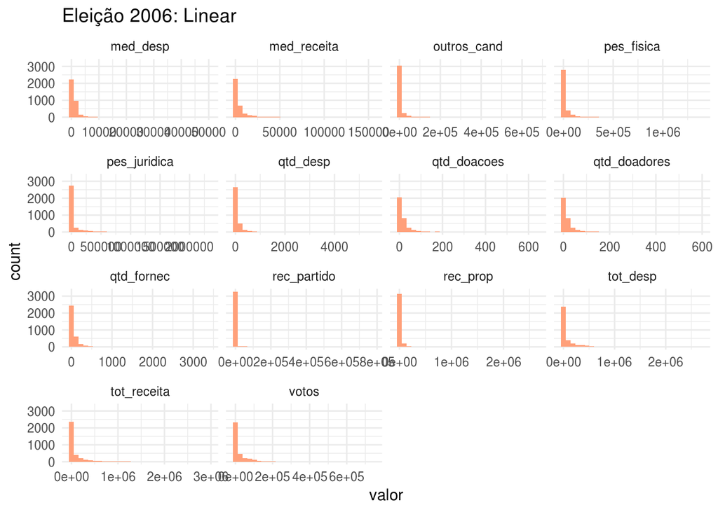

```r
select_2006 %>%
  gather(key = "variavel",
         value = "valor") %>%
  ggplot(aes(x = valor)) +
  geom_histogram(bins = 30,
                 fill = "#FFA07A") +
  facet_wrap(~variavel, scales = "free_x") +
  labs(title = "Eleição 2006: Linear")
```

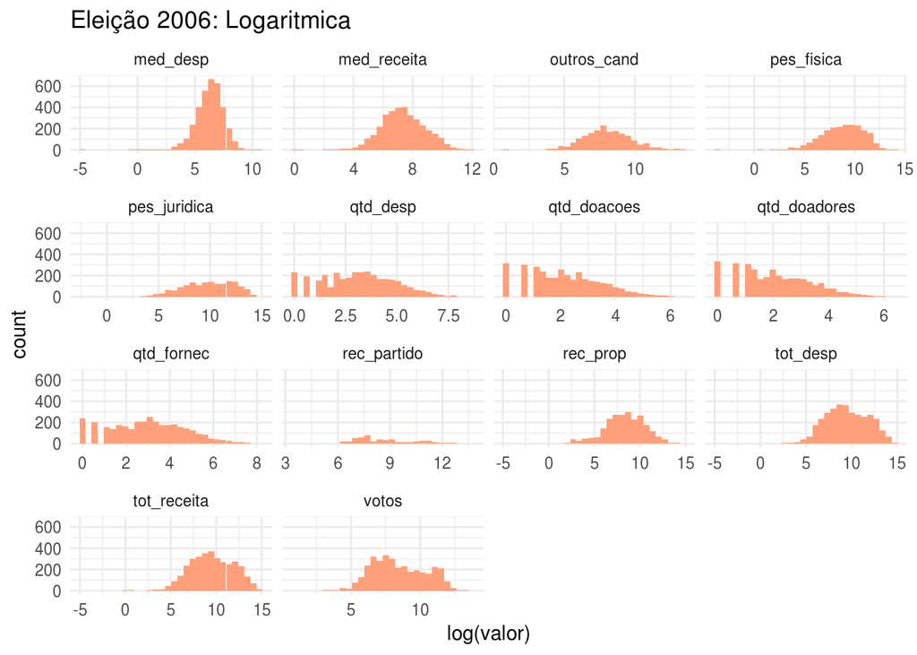

```r
select_2006 %>%
  gather(key = "variavel",
         value = "valor") %>%
  ggplot(aes(x = log(valor))) +
  geom_histogram(bins = 30,
                 fill = "#FFA07A") +
  facet_wrap(~variavel, scales = "free_x") +
  labs(title = "Eleição 2006: Logaritmica")
```

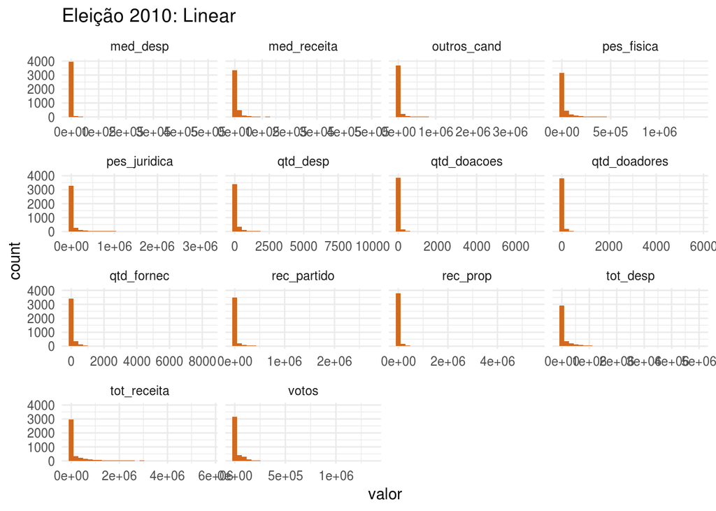

```r
select_2010 %>%
  gather(key = "variavel",
         value = "valor") %>%
  ggplot(aes(x = valor)) +
  geom_histogram(bins = 30,
                 fill = "#D2691E") +
  facet_wrap(~variavel, scales = "free_x") +
  labs(title = "Eleição 2010: Linear")
```

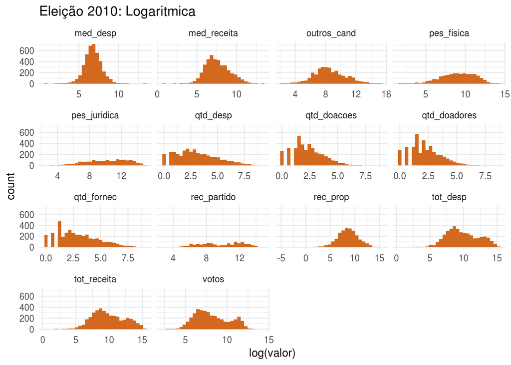

```r
select_2010 %>%
  gather(key = "variavel",
         value = "valor") %>%
  ggplot(aes(x = log(valor))) +
  geom_histogram(bins = 30,
                 fill = "#D2691E") +
  facet_wrap(~variavel, scales = "free_x") +
  labs(title = "Eleição 2010: Logaritmica")
```

Podemos observar que temos uma maior ocorrência da variável de média de despesas e a com menor ocorrência é recursos do partido para ambas as eleições.

### 1. Um modelo de regressão múltipla com todas as variáveis é plausível para explicar a variação em y (número de votos) em 2006? Mesma pergunta para 2010.

Para verificar se todas as variáveis são necessárias para nosso modelo iremos fazer alguns procedimentos. O primeiro deles foi descartar as variáveis cargo, nome, sequencial do candidato e o ano, já que não são tão importantes para a regressão, pois algumas delas repetem o nível em todas as ocorrências da base de dados.

```r
eleicao_2006_mod <- eleicao_2006 %>%
  select(-cargo,
         -nome,
         -sequencial_candidato,
         -ano)
```

O segundo passo é fazer a regressão, optei por omitir os dados vazios(NA) para não influenciar no resultado final.

```r
modelo_tot_06 <- lm(votos ~ .,
                    data = eleicao_2006_mod,
                    na.action = na.omit)
```

Depois do modelo traçado, podemos ver as variáveis com alta e baixa significância para o modelo.

```r
summary(modelo_tot_06)
```

```
##
## Call:
## lm(formula = votos ~ ., data = eleicao_2006_mod, na.action = na.omit)
##
## Residuals:
##     Min      1Q  Median      3Q     Max
## -210176   -8531   -1929    3749  633232
##
## Coefficients: (1 not defined because of singularities)
##                                                                                  Estimate
## (Intercept)                                                                    -1.865e+04
## ufAL                                                                            1.433e+04
## ufAM                                                                            1.675e+04
## ufAP                                                                            3.688e+03
## ufBA                                                                            2.704e+04
## ufCE                                                                            2.929e+04
## ufDF                                                                            9.075e+03
## ufES                                                                            1.431e+04
## ufGO                                                                            1.284e+04
## ufMA                                                                            2.418e+04
## ufMG                                                                            1.733e+04
## ufMS                                                                            1.230e+04
## ufMT                                                                            9.713e+03
## ufPA                                                                            2.563e+04
## ufPB                                                                            2.561e+04
## ufPE                                                                            2.052e+04
## ufPI                                                                            2.055e+04
## ufPR                                                                            1.859e+04
## ufRJ                                                                            1.632e+04
## ufRN                                                                            3.601e+04
## ufRO                                                                            1.155e+04
## ufRR                                                                            6.727e+03
## ufRS                                                                            2.120e+04
## ufSC                                                                            2.115e+04
## ufSE                                                                            1.982e+04
## ufSP                                                                            1.795e+04
## ufTO                                                                            5.091e+03
## partidoPCB                                                                     -1.243e+03
## partidoPC do B                                                                  6.457e+03
## partidoPCO                                                                     -6.785e+02
```

[output cut: 1080 more lines]

```
## ocupacaoTRABALHADOR DOS SERVIÇOS DE CONTABILIDADE, DE CAIXA E ASSEMELHADOS
## ocupacaoTRABALHADOR EM ATIVIDADE DE PROCESSAMENTO QUÍMICO
## ocupacaoTRABALHADOR METALÚRGICO E SIDERÚRGICO
## ocupacaoVENDEDOR DE COMÉRCIO VAREJISTA E ATACADISTA
## ocupacaoVENDEDOR PRACISTA, REPRESENTANTE, CAIXEIRO-VIAJANTE E ASSEMELHADOS
## ocupacaoVEREADOR
## ocupacaoVETERINÁRIO
## ocupacaoVIGILANTE
## ocupacaoZOOTECNISTA
## ---
## Signif. codes:  0 '***' 0.001 '**' 0.01 '*' 0.05 '.' 0.1 ' ' 1
##
## Residual standard error: 30540 on 3214 degrees of freedom
## Multiple R-squared:  0.5779, Adjusted R-squared:  0.5488
## F-statistic: 19.91 on 221 and 3214 DF,  p-value: < 2.2e-16
```

Dessa forma, podemos observar que variáveis com total de despesa, recursos de pessoas física e jurídicas tem um maior nível de significância, podemos observar isso pela presença dos 3 asteriscos ao lado do p-valor. Além dessa informação, também podemos observar o R-quadrado(representa a proporção da variabilidade na variável resposta explicada pela variável preditora) com o valor de 0.5779 e com R-ajustado(é a porcentagem de variação na resposta que é explicada pelo modelo, ajustada para o número de preditores do modelo em relação ao número de observações) com o valor de 0.5488 e p-valor menor que 2.2e-16, número muito próximo de zero, fazendo com que seja um bom modelo.

```r
print(mean(modelo_tot_06$residuals))
```

```
## [1] 2.522858e-13
```

O valor da média dos resíduos está bem próximo de zero.

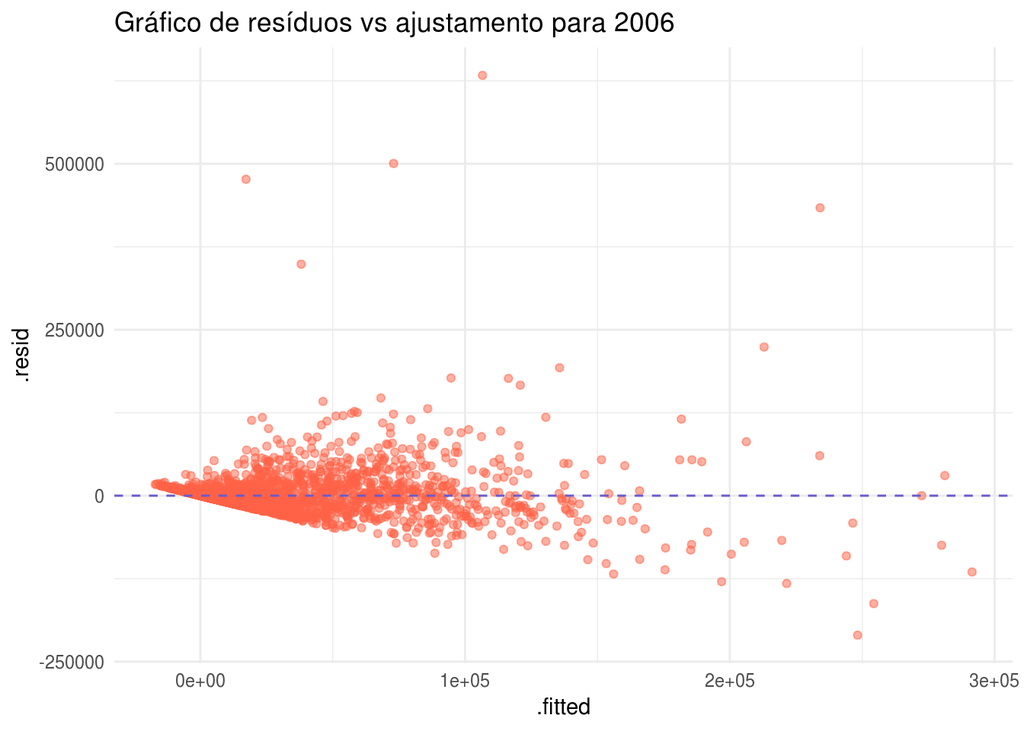

```r
modelo_tot_06 %>%
  ggplot(aes(.fitted, .resid)) +
  geom_jitter(alpha = .5,
              color = "#FF6347") +
  geom_hline(yintercept = 0,
             color = "#6A5ACD",
             linetype = "dashed") +
  labs(title = "Gráfico de resíduos vs ajustamento para 2006")
```

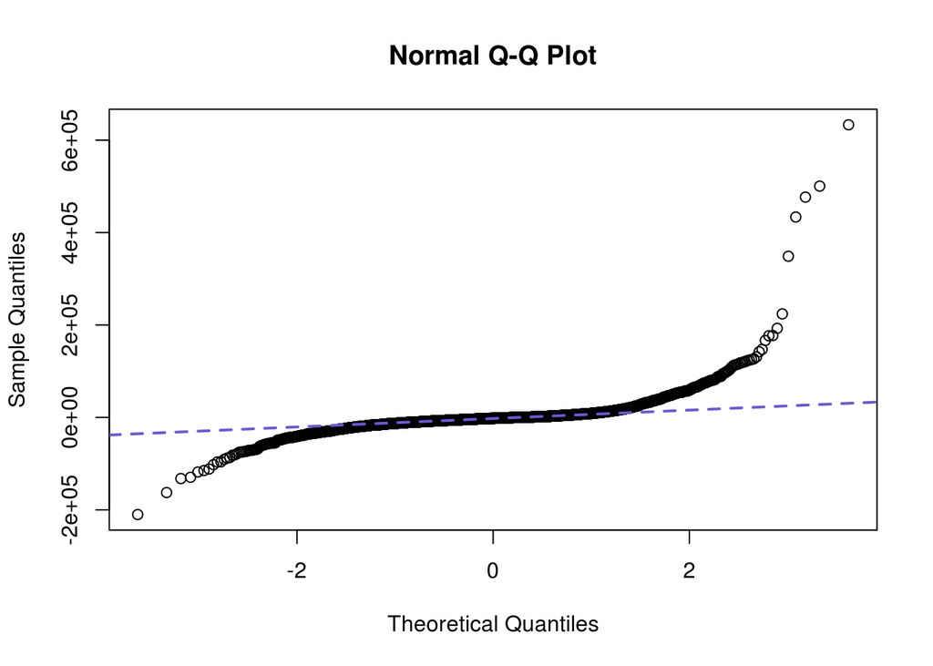

```r
qqnorm(modelo_tot_06$residuals)
qqline(modelo_tot_06$residuals,
       col = "#6A5ACD",
       lwd = 2,
       lty = 2)
```

Para traçar um modelo bom, o ideal é que os resíduos(pontos) fiquem o mais próximo da linha pontilhada.

Da mesma maneira, vamos fazer os passos para as eleições de 2010.

```r
eleicao_2010_mod <- eleicao_2010 %>%
  select(-cargo,
         -nome,
         -sequencial_candidato,
         -ano)
```

```r
modelo_tot_10 <- lm(votos ~ .,
                    data = eleicao_2010_mod,
                    na.action = na.omit)
```

```r
summary(modelo_tot_10)
```

```
##
## Call:
## lm(formula = votos ~ ., data = eleicao_2010_mod, na.action = na.omit)
##
## Residuals:
##     Min      1Q  Median      3Q     Max
## -215328   -9229   -2196    4197 1044580
##
## Coefficients:
##                                                                                  Estimate
## (Intercept)                                                                    -5.792e+03
## ufAL                                                                            1.918e+04
## ufAM                                                                            2.220e+04
## ufAP                                                                            7.398e+03
## ufBA                                                                            2.240e+04
## ufCE                                                                            3.653e+04
## ufDF                                                                            1.721e+04
## ufES                                                                            1.442e+04
## ufGO                                                                            9.235e+03
## ufMA                                                                            2.004e+04
## ufMG                                                                            1.357e+04
## ufMS                                                                            8.732e+03
## ufMT                                                                            9.238e+03
## ufPA                                                                            2.880e+04
## ufPB                                                                            2.277e+04
## ufPE                                                                            2.475e+04
## ufPI                                                                            2.015e+04
## ufPR                                                                            1.796e+04
## ufRJ                                                                            1.068e+04
## ufRN                                                                            2.234e+04
## ufRO                                                                            1.023e+04
## ufRR                                                                           -5.508e+03
## ufRS                                                                            1.893e+04
## ufSC                                                                            1.910e+04
## ufSE                                                                            1.462e+04
## ufSP                                                                            1.628e+04
## ufTO                                                                           -3.015e+03
## partidoPCB                                                                     -9.441e+03
## partidoPC do B                                                                 -2.216e+03
## partidoPCO                                                                     -1.223e+04
```

[output cut: 1115 more lines]

```
## ocupacaoTRABALHADOR DE USINAGEM DE METAIS
## ocupacaoTRABALHADOR DOS SERVIÇOS DE CONTABILIDADE, DE CAIXA E ASSEMELHADOS
## ocupacaoTRABALHADOR METALÚRGICO E SIDERÚRGICO
## ocupacaoTRABALHADOR RURAL
## ocupacaoVENDEDOR DE COMÉRCIO VAREJISTA E ATACADISTA
## ocupacaoVENDEDOR PRACISTA, REPRESENTANTE, CAIXEIRO-VIAJANTE E ASSEMELHADOS
## ocupacaoVEREADOR
## ocupacaoVETERINÁRIO
## ocupacaoVIGILANTE
## ---
## Signif. codes:  0 '***' 0.001 '**' 0.01 '*' 0.05 '.' 0.1 ' ' 1
##
## Residual standard error: 34590 on 3810 degrees of freedom
## Multiple R-squared:  0.5405, Adjusted R-squared:  0.5129
## F-statistic: 19.57 on 229 and 3810 DF,  p-value: < 2.2e-16
```

Já para as eleições de 2010, as variáveis que tiveram maior significância foram total de despesa e média de receita. Já para os valores de R-quadrado 0.5405, R-ajustado 0.5129 e p-valor menor que 2.2e-16, também bem pequeno, quase próximo de zero.

```r
print(mean(modelo_tot_10$residuals))
```

```
## [1] 3.874041e-14
```

Para a média dos resíduos, também temos um bom valor, bem próximo de zero.

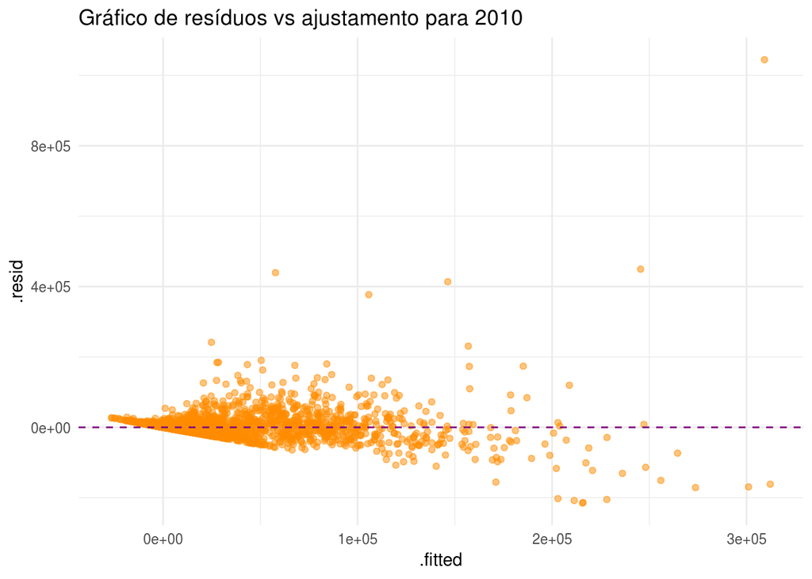

```r
modelo_tot_10 %>%
  ggplot(aes(.fitted, .resid)) +
  geom_jitter(alpha = .5,
              color = "darkorange") +
  geom_hline(yintercept = 0,
             color = "#800080",
             linetype = "dashed") +
  labs(title = "Gráfico de resíduos vs ajustamento para 2010")
```

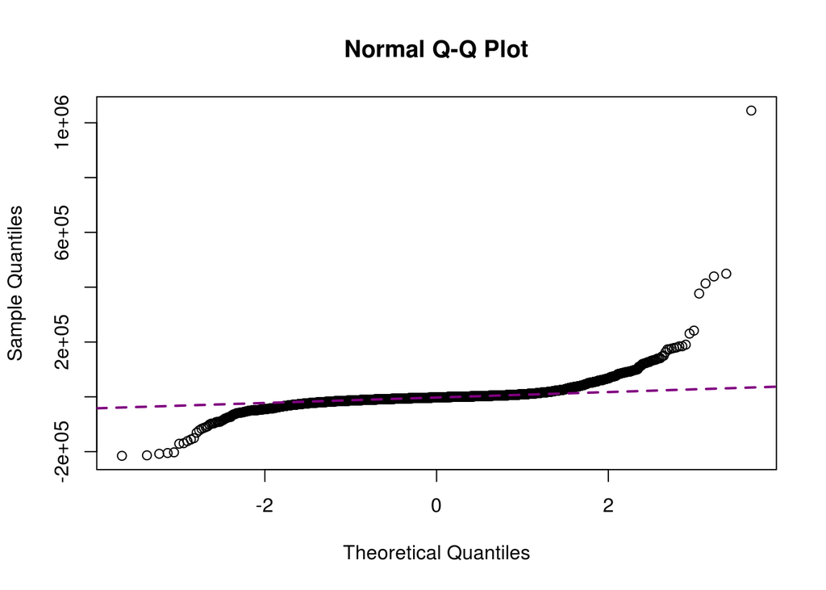

```r
qqnorm(modelo_tot_10$residuals)
qqline(modelo_tot_10$residuals,
       col = "#800080",
       lwd = 2,
       lty = 2)
```

Depois de visto todas as informações acima, podemos traçar um modelo para cada eleição com uma quantidade menor de variáveis, já muitas delas tem pouca significância para se fazer uma regressão.

### 2.Compare as regressões construídas para 2006 e 2010. Quais as diferenças/semelhanças percebidas? Algumas sugestões:

Analise os plots de resíduos e verifique se há tendências nos erros para cada ano. Quais variáveis conseguem explicar melhor o número de votos? Compare essas variáveis entre os modelos. Mesma coisa para as variáveis menos explicativas. Compare os valores de R2 e RSE considerando as regressões para cada ano. Inclua outros pontos de comparação que você ache interessante.

Nos passos anteriores, fizemos uma breve análise dos dados, e podemos ver que os modelos tem algumas semelhanças, como o p-valor que são bem baixos, quase próximos de zero. No entanto diferem nos valores de R-quadrado, R-ajustado e variáveis com maior significância, com apenas total de despesa em comum.

### 3.Todas as variáveis são úteis para os modelos de regressão? Há variáveis redudantes? Faça análises para 2006 e 2010 separadamente.

Para responder essa pergunta, utilizamos o dataframe que retiramos as variáveis categóricas.

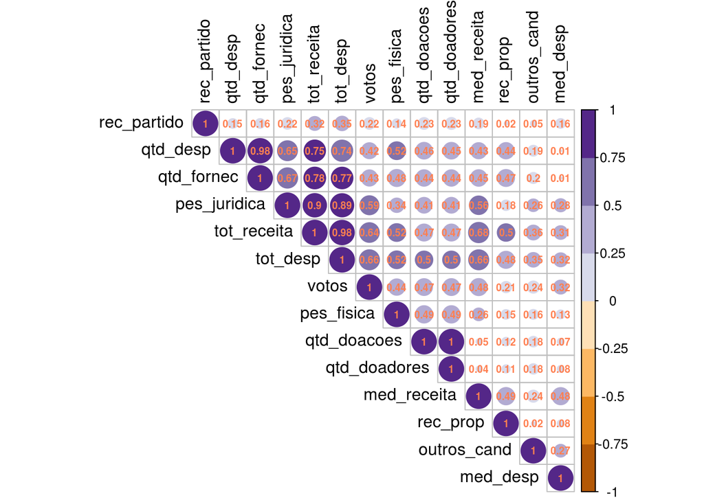

```r
# 2006
correlacao_06 <- select_2006 %>%
  cor()

corrplot(correlacao_06, type = "upper",
         order = "hclust",
         number.cex = .6,
         addCoef.col = "#FF7F50",
         tl.col = "black", tl.srt = 90,
         col = brewer.pal(n = 8, name = "PuOr"))
```

Para o ano de 2006, de acordo com o correlograma, temos algumas variáveis com maior valor de correlação, mostrada com cores mais fortes. Dessa forma, para selecionar as melhores variáveis, selecionei as que possuem maior correlação com votos, já que queremos explicar quais impactam mais na decisão de votos nas eleições, e as tinham maior correlação entre si para posteriormente retirar as que são redundantes.

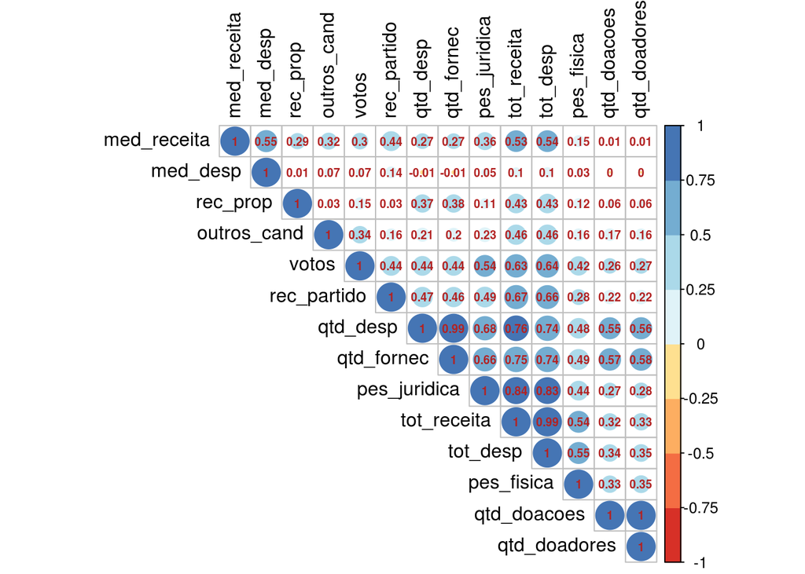

```r
# 2010
correlacao_10 <- select_2010 %>%
  cor()

corrplot(correlacao_10, type = "upper",
         order = "hclust",
         number.cex = .6,
         addCoef.col = "#B22222",
         tl.col = "black", tl.srt = 90,
         col = brewer.pal(n = 8, name = "RdYlBu"))
```

Utizando as mesma técnicas, podemos observar que pelo correlograma total de despesa foi a variável com maior relação com votos em 2010.

### 4.No caso de haver variáveis pouco explicativas e/ou redudantes, construa um novo modelo sem essas variáveis e o compare ao modelo com todas as variáveis (e.g. em termos de R2 e RSE). Faça isso para 2006 e 2010 separadamente.

Dessa forma, utilzando as variáveis com forte significância e maior correlação pelo correlograma, podemos traçar os modelos para 2006 e 2010 com uma quantidade menor de variáveis.

Para 2006:

```r
a <- eleicao_2006 %>%
  select(votos,
         total_despesa,
         total_receita,
         media_receita,
         recursos_de_pessoas_fisicas,
         recursos_de_pessoas_juridicas)
```

```r
modelo_06 <- lm(votos ~ .,
                data = a,
                na.action = na.omit)
```

```r
print(mean(modelo_06$residuals))
```

```
## [1] -2.65925e-12
```

```r
summary(modelo_06)
```

```
##
## Call:
## lm(formula = votos ~ ., data = a, na.action = na.omit)
##
## Residuals:
##     Min      1Q  Median      3Q     Max
## -256366   -8224   -7023   -1049  650064
##
## Coefficients:
##                                 Estimate Std. Error t value Pr(>|t|)
## (Intercept)                    7.732e+03  6.459e+02  11.971   <2e-16 ***
## total_despesa                  1.811e-01  1.276e-02  14.194   <2e-16 ***
## total_receita                 -1.291e-01  1.279e-02 -10.093   <2e-16 ***
## media_receita                  8.390e-01  9.002e-02   9.321   <2e-16 ***
## recursos_de_pessoas_fisicas    1.920e-01  1.460e-02  13.151   <2e-16 ***
## recursos_de_pessoas_juridicas  6.666e-02  7.367e-03   9.047   <2e-16 ***
## ---
## Signif. codes:  0 '***' 0.001 '**' 0.01 '*' 0.05 '.' 0.1 ' ' 1
##
## Residual standard error: 33070 on 3430 degrees of freedom
## Multiple R-squared:  0.4719, Adjusted R-squared:  0.4711
## F-statistic: 612.9 on 5 and 3430 DF,  p-value: < 2.2e-16
```

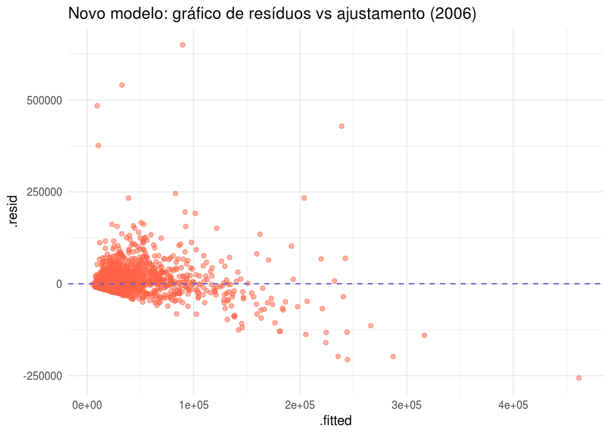

```r
modelo_06 %>%
  ggplot(aes(.fitted, .resid)) +
  geom_jitter(alpha = .5,
              color = "#FF6347") +
  geom_hline(yintercept = 0,
             color = "#6A5ACD",
             linetype = "dashed") +
  labs(title = "Novo modelo: gráfico de resíduos vs ajustamento (2006)")
```

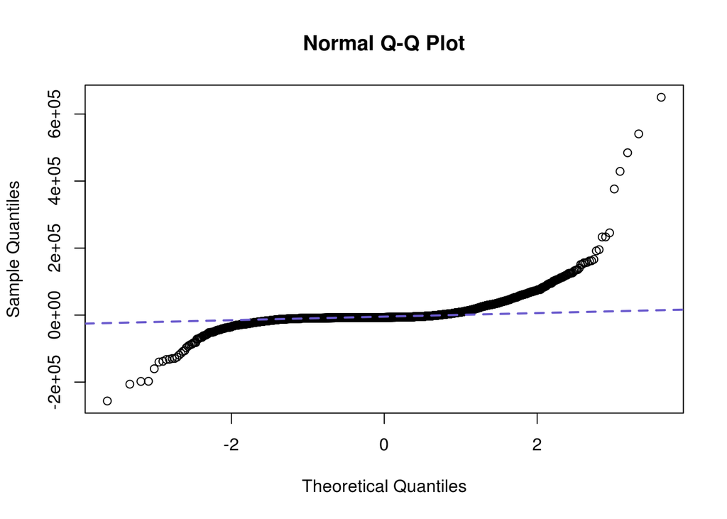

```r
qqnorm(modelo_06$residuals)
qqline(modelo_06$residuals,
       col = "#6A5ACD",
       lwd = 2,
       lty = 2)
```

Para 2010:

```r
b <- select_2010 %>%
  select(votos,
         tot_desp,
         pes_juridica,
         pes_fisica,
         rec_partido
         )
```

```r
modelo_10 <- lm(votos ~ .,
                data = b,
                na.action = na.omit)
```

```r
print(mean(modelo_10$residuals))
```

```
## [1] 5.559452e-13
```

```r
summary(modelo_10)
```

```
##
## Call:
## lm(formula = votos ~ ., data = b, na.action = na.omit)
##
## Residuals:
##     Min      1Q  Median      3Q     Max
## -196866   -8191   -7446   -3367 1305283
##
## Coefficients:
##               Estimate Std. Error t value Pr(>|t|)
## (Intercept)  8.315e+03  6.525e+02  12.742  < 2e-16 ***
## tot_desp     4.933e-02  2.814e-03  17.534  < 2e-16 ***
## pes_juridica 1.184e-02  3.729e-03   3.176 0.001507 **
## pes_fisica   6.996e-02  9.094e-03   7.693 1.79e-14 ***
## rec_partido  1.652e-02  4.603e-03   3.590 0.000335 ***
## ---
## Signif. codes:  0 '***' 0.001 '**' 0.01 '*' 0.05 '.' 0.1 ' ' 1
##
## Residual standard error: 37910 on 4035 degrees of freedom
## Multiple R-squared:  0.4155, Adjusted R-squared:  0.4149
## F-statistic: 717.1 on 4 and 4035 DF,  p-value: < 2.2e-16
```

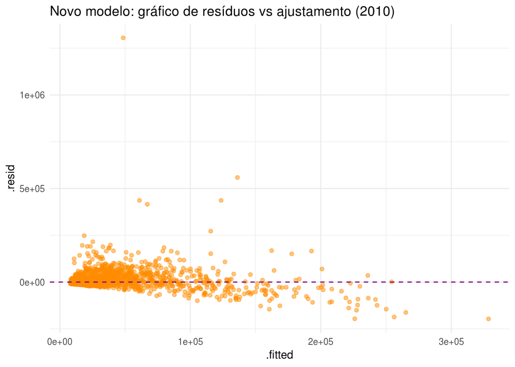

```r
modelo_10 %>%
  ggplot(aes(.fitted, .resid)) +
  geom_jitter(alpha = .5,
              color = "darkorange") +
  geom_hline(yintercept = 0,
             color = "#800080",
             linetype = "dashed") +
  labs(title = "Novo modelo: gráfico de resíduos vs ajustamento (2010)")
```

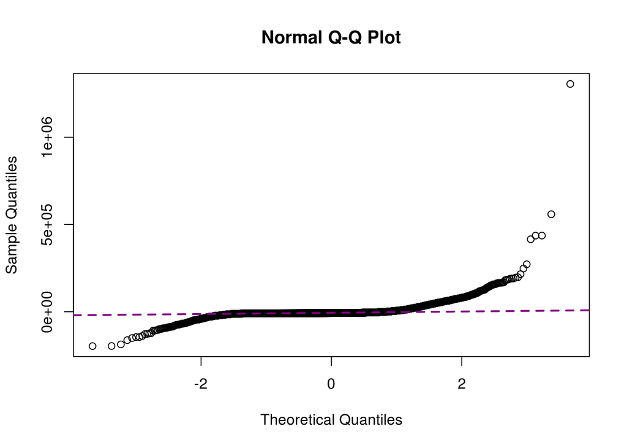

```r
qqnorm(modelo_10$residuals)
qqline(modelo_10$residuals,
       col = "#800080",
       lwd = 2,
       lty = 2)
```

Assim como no modelo com todas as variáveis temos valores baixos para p-valor e resíduos, que é uma métrica legal para um bom modelo, além de serem compostos por variáveis com alto nível de significância.

### 5.Construa agora uma regressão considerando os anos 2006 e 2010 em conjunto. Que diferenças/semelhanças você percebe em relação aos modelos individuais por ano? Veja a questão 2 para sugestões que você usar para comparação.

Repetindo os mesmos procedimentos anteriores para encontrar variáveis com maior significância:

```r
eleicao_06_10_mod <- eleicao_2006_2010 %>%
  select(-cargo,
         -nome,
         -sequencial_candidato,
         -ano)
```

```r
modelo_tot_06_10 <- lm(votos ~ .,
                    data = eleicao_06_10_mod,
                    na.action = na.omit)
```

```r
summary(modelo_tot_06)
```

```
##
## Call:
## lm(formula = votos ~ ., data = eleicao_2006_mod, na.action = na.omit)
##
## Residuals:
##     Min      1Q  Median      3Q     Max
## -210176   -8531   -1929    3749  633232
##
## Coefficients: (1 not defined because of singularities)
##                                                                                  Estimate
## (Intercept)                                                                    -1.865e+04
## ufAL                                                                            1.433e+04
## ufAM                                                                            1.675e+04
## ufAP                                                                            3.688e+03
## ufBA                                                                            2.704e+04
## ufCE                                                                            2.929e+04
## ufDF                                                                            9.075e+03
## ufES                                                                            1.431e+04
## ufGO                                                                            1.284e+04
## ufMA                                                                            2.418e+04
## ufMG                                                                            1.733e+04
## ufMS                                                                            1.230e+04
## ufMT                                                                            9.713e+03
## ufPA                                                                            2.563e+04
## ufPB                                                                            2.561e+04
## ufPE                                                                            2.052e+04
## ufPI                                                                            2.055e+04
## ufPR                                                                            1.859e+04
## ufRJ                                                                            1.632e+04
## ufRN                                                                            3.601e+04
## ufRO                                                                            1.155e+04
## ufRR                                                                            6.727e+03
## ufRS                                                                            2.120e+04
## ufSC                                                                            2.115e+04
## ufSE                                                                            1.982e+04
## ufSP                                                                            1.795e+04
## ufTO                                                                            5.091e+03
## partidoPCB                                                                     -1.243e+03
## partidoPC do B                                                                  6.457e+03
## partidoPCO                                                                     -6.785e+02
```

[output cut: 1080 more lines]

```
## ocupacaoTRABALHADOR DOS SERVIÇOS DE CONTABILIDADE, DE CAIXA E ASSEMELHADOS
## ocupacaoTRABALHADOR EM ATIVIDADE DE PROCESSAMENTO QUÍMICO
## ocupacaoTRABALHADOR METALÚRGICO E SIDERÚRGICO
## ocupacaoVENDEDOR DE COMÉRCIO VAREJISTA E ATACADISTA
## ocupacaoVENDEDOR PRACISTA, REPRESENTANTE, CAIXEIRO-VIAJANTE E ASSEMELHADOS
## ocupacaoVEREADOR
## ocupacaoVETERINÁRIO
## ocupacaoVIGILANTE
## ocupacaoZOOTECNISTA
## ---
## Signif. codes:  0 '***' 0.001 '**' 0.01 '*' 0.05 '.' 0.1 ' ' 1
##
## Residual standard error: 30540 on 3214 degrees of freedom
## Multiple R-squared:  0.5779, Adjusted R-squared:  0.5488
## F-statistic: 19.91 on 221 and 3214 DF,  p-value: < 2.2e-16
```

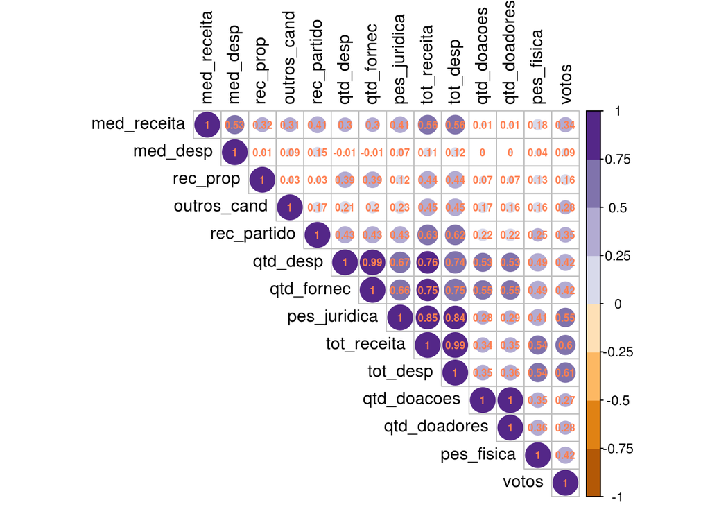

```r
correlacao_06_10 <- select_2006_2010 %>%
  cor()

corrplot(correlacao_06_10, type = "upper",
         order = "hclust",
         number.cex = .6,
         addCoef.col = "#FF7F50",
         tl.col = "black", tl.srt = 90,
         col = brewer.pal(n = 8, name = "PuOr"))
```

Obs.: também utilizei as variáveis com maior significância feito anteriormente.

```r
c <- eleicao_2006_2010 %>%
  select(votos,
         total_despesa,
         total_receita,
         recursos_de_outros_candidatos.comites,
         recursos_de_pessoas_fisicas,
         recursos_de_pessoas_juridicas,
         quantidade_doacoes
         )
```

```r
modelo_tot_06_10 <- lm(votos ~ .,
                    data = c,
                    na.action = na.omit)
```

```r
print(mean(modelo_tot_06_10$residuals))
```

```
## [1] -5.822655e-12
```

```r
summary(modelo_tot_06_10)
```

```
##
## Call:
## lm(formula = votos ~ ., data = c, na.action = na.omit)
##
## Residuals:
##     Min      1Q  Median      3Q     Max
## -316533   -9662   -8660   -2900 1313392
##
## Coefficients:
##                                         Estimate Std. Error t value
## (Intercept)                            9.823e+03  4.657e+02  21.095
## total_despesa                          9.894e-02  7.368e-03  13.429
## total_receita                         -5.543e-02  6.755e-03  -8.206
## recursos_de_outros_candidatos.comites  3.166e-02  4.876e-03   6.492
## recursos_de_pessoas_fisicas            9.809e-02  7.849e-03  12.498
## recursos_de_pessoas_juridicas          4.421e-02  3.433e-03  12.878
## quantidade_doacoes                     1.323e+01  3.977e+00   3.326
##                                       Pr(>|t|)
## (Intercept)                            < 2e-16 ***
## total_despesa                          < 2e-16 ***
## total_receita                         2.67e-16 ***
## recursos_de_outros_candidatos.comites 9.02e-11 ***
## recursos_de_pessoas_fisicas            < 2e-16 ***
## recursos_de_pessoas_juridicas          < 2e-16 ***
## quantidade_doacoes                    0.000886 ***
## ---
## Signif. codes:  0 '***' 0.001 '**' 0.01 '*' 0.05 '.' 0.1 ' ' 1
##
## Residual standard error: 36930 on 7469 degrees of freedom
## Multiple R-squared:  0.4018, Adjusted R-squared:  0.4013
## F-statistic: 836.2 on 6 and 7469 DF,  p-value: < 2.2e-16
```

Para esse modelo, temos valores bem parecidos com os feitos anteriormente, com valores de p-valor e resíduos próximos a zero. No entanto, o R-quadrado e R-ajustado tiveram valores mais baixos.

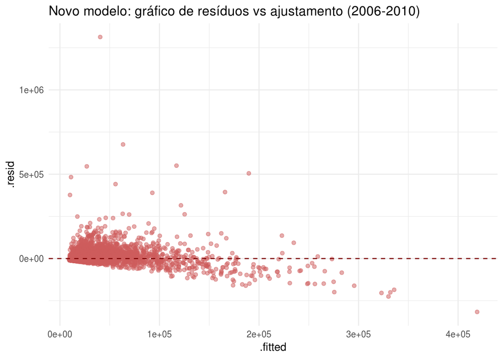

```r
modelo_tot_06_10 %>%
  ggplot(aes(.fitted, .resid)) +
  geom_jitter(alpha = .5,
              color = "#CD5C5C") +
  geom_hline(yintercept = 0,
             color = "#800000",
             linetype = "dashed") +
  labs(title = "Novo modelo: gráfico de resíduos vs ajustamento (2006-2010)")
```

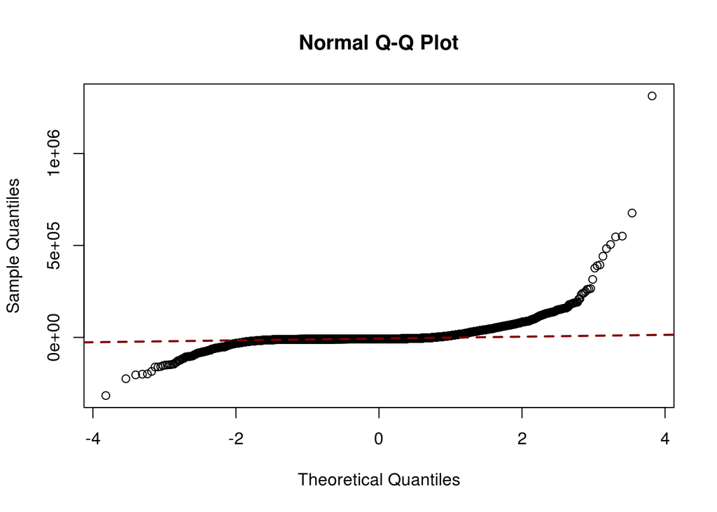

```r
qqnorm(modelo_tot_06_10$residuals)
qqline(modelo_tot_06_10$residuals,
       col = "#800000",
       lwd = 2,
       lty = 2)
```

Para os gráficos acima, podemos observar que o novo modelo para 2006 e 2010, os pontos do plot de resíduos vs ajustamento estão menos concentrados, no entanto ainda tendenciosos.